# Corrigé : Apprentissage automatique pour la génomique

Prédiction de la résistance à la ciprofloxacine chez *E. coli* : phénotypage non supervisé et prédiction supervisée

Auteur·rice

DU Bioinformatique, UM6SS

Date de publication

12 septembre 2026

**Important**

Ce document est le **corrigé complet** du projet (`projet-enonce.qmd`). Il ne doit pas être distribué aux étudiants avant la remise de leur travail.

# 1 Déroulé de l’analyse

```
import des données
      │
compréhension des données
      │
prétraitement
      │
hypothèses de travail
      │
   ┌──┴───────────────────────┐
apprentissage non supervisé   apprentissage supervisé
(phynotype)                    (funcml)
cluster -> valider ->          registre -> comparer -> régler ->
explorer -> interpréter ->     ajuster -> rééchantillonner ->
prédire                        prédire -> interpréter
   └──┬───────────────────────┘
      ▼
lecture croisée : le phénotype non supervisé aide-t-il le modèle supervisé ?
```

Le volet non supervisé cherche *quels groupes d’isolats existent*, sans utiliser l’étiquette de résistance. Le volet supervisé cherche *peut-on prédire la résistance*, et utilise le phénotype trouvé en amont comme une variable candidate parmi d’autres.

# 2 Import des données

```r
library(basetable)

raw <- btread("ecoli_amr_isolate_v2.csv")
dim(raw)
```

```
[1] 700  20
```

# 3 Compréhension des données

```r
library(basetable)

preview(raw)
```

```
Rows: 700  Columns: 20
$ genome_id <numeric> 562.144939, 562.144952, 562.144964
$ mlst <character> MLST.Escherichia_coli_2.88, MLST.ecoli_achtman_4.10, MLST.eco
$ contigs <integer> 274, 281, 162
$ genome_name <character> Escherichia coli MGL_133, Escherichia coli PT_EC0171,
$ genome_quality <character> Good, Good, Good
$ isolation_country <character> India, Portugal, Portugal
$ genome_length <integer> 5243656, 5312076, 4873141
$ gc_content <numeric> 50.726078, 50.175243, 50.922268
$ host_name <character> Human, Homo sapiens, Pig, Sus scrofa, wild boar
$ collection_year <integer> NA, 2021, 2020
$ isolation_source <character> NA, Faeces, Faeces
$ host_group <character> NA, NA, NA
$ ampicillin <character> Resistant, Susceptible, NA
$ cefotaxime <character> NA, Susceptible, NA
$ ceftazidime <character> NA, NA, Susceptible
$ ciprofloxacin <character> Resistant, Susceptible, Susceptible
$ gentamicin <character> NA, NA, NA
$ meropenem <character> NA, NA, Susceptible
$ pip_taz <character> NA, NA, NA
$ sxt <character> Resistant, NA, NA
```

```r
count(raw, by = "ciprofloxacin")
```

```
# basetable: 3 x 2
  ciprofloxacin   n
1   Susceptible 539
2     Resistant 144
3  Intermediate  17
```

Une ligne = un isolat d’*E. coli* : caractéristiques d’assemblage (`genome_length`, `gc_content`, `contigs`, `mlst`), métadonnées (`isolation_country`, `host_name`, `collection_year`), et phénotypes AST pour 8 antibiotiques, dont `ciprofloxacin`, la cible du volet supervisé.

La ciprofloxacine est une fluoroquinolone, antimicrobien critique de priorité maximale selon l’OMS et traitement oral de première ligne pour les infections urinaires et bactériémies à *E. coli* ; la perdre restreint les options à des molécules généralement injectables, plus toxiques, ou les deux. Biologiquement, la résistance est surtout acquise par mutations chromosomiques ponctuelles dans les régions déterminant la résistance aux quinolones (QRDR) de `gyrA` (ADN gyrase) et `parC` (topoisomérase IV), les enzymes ciblées par la ciprofloxacine, qui produisent individuellement des sauts nets de concentration minimale inhibitrice. C’est pourquoi la séparation résistant/sensible est en général propre et bimodale pour cet antibiotique, même selon différentes méthodes de ML (Anahtar, Yang, et Kanjilal 2021), contrairement à des antibiotiques aux distributions de CMI continues et chevauchantes : une partie de la “facilité” de classification obtenue plus bas tient au mécanisme de l’antibiotique, pas seulement aux variables utilisées.

# 4 Prétraitement

Objectifs : une ligne par isolat, une cible binaire propre, et deux types de valeurs manquantes traités différemment. Un résultat AST jamais réalisé (“non testé”) est codé comme catégorie explicite : l’imputer fabriquerait un résultat clinique qui n’a jamais été mesuré. `isolation_country`, à l’inverse, est une métadonnée de collecte : manquante parce qu’un enregistrement est incomplet, pas parce qu’un test a été sauté. C’est une cible légitime d’imputation, réalisée avec `missknn::missknn()` [imputation par k plus proches voisins masqués sur les variables d’assemblage et de métadonnées observées conjointement], plutôt que regroupée dans une catégorie “Inconnu” générique, ce qui confondrait des enregistrements réellement manquants avec une vraie catégorie “pays rare/inconnu” et ajouterait du bruit exactement là où **H3** en a le moins besoin.

```r
install.packages("pak")
pak::pak("ielbadisy/missknn")
```

```r
library(missknn)

abx_other <- c("ampicillin", "cefotaxime", "meropenem", "sxt",
               "ceftazidime", "gentamicin", "pip_taz")

iso <- raw |>
  uniquerows(cols = "genome_id", .keep_all = TRUE) |>
  subset(ciprofloxacin %in% c("Resistant", "Susceptible")) |>
  transform(
    cipro_R  = factor(ifelse(ciprofloxacin == "Resistant", "R", "S"), levels = c("S", "R")),
    host_grp = factor(ifelse(is.na(host_name), "Unknown",
                      ifelse(grepl("Homo sapiens", host_name), "Human", "Animal/other")))
  )

# isolation_country : métadonnée imputable (missknn), contrairement aux AST
country_imp <- iso[, c("isolation_country", "genome_length", "gc_content",
                        "contigs", "collection_year")]
country_imp$isolation_country <- factor(country_imp$isolation_country)
imp <- missknn(country_imp, k = 5, seed = 2026)
iso$isolation_country <- complete(imp)$isolation_country

# pays rares regroupés ("Other" = rare, pas manquant) pour éviter des niveaux absents d'un pli de CV
frequent_countries <- names(which(table(iso$isolation_country) >= 25))
iso$country_grp <- factor(ifelse(
  iso$isolation_country %in% frequent_countries,
  as.character(iso$isolation_country), "Other"
))

# co-résistance : NA = "non testé", catégorie structurelle, non imputée
for (a in abx_other) iso[[a]] <- factor(nato(iso[[a]], "Not_tested"))

iso <- pick(iso, c("genome_id", "cipro_R",
                   "genome_length", "gc_content", "contigs",
                   abx_other, "host_grp", "country_grp"))
iso <- iso[complete.cases(iso), ]

dim(iso)
```

```
[1] 683  14
```

```r
count(iso, by = "cipro_R")
```

```
# basetable: 2 x 2
  cipro_R   n
1       S 539
2       R 144
```

```r
prev <- mean(iso$cipro_R == "R")
round(prev, 3)
```

```
[1] 0.211
```

La prévalence de résistance est d’environ 21% : une cible **déséquilibrée**, ce qui oriente le choix des métriques dans le volet supervisé. Le déséquilibre de classes est l’une des propriétés structurelles des données génomiques qui met le plus souvent en défaut les outils par défaut : l’exactitude et même l’AUC-ROC peuvent sembler trompeusement élevées sur la classe majoritaire alors que le modèle est peu informatif pour la classe minoritaire (Whalen et al. 2022), d’où le choix, plus bas, de rapporter le score de Brier, la calibration et une lecture précision/rappel de la ROC (Saito et Rehmsmeier 2015) en complément de l’AUC seule.

# 5 Hypothèses de travail

- **H1, co-résistance.** Les autres phénotypes bêta-lactamines/ aminosides (`cefotaxime`, `ceftazidime`, `gentamicin`) sont-ils associés à la résistance ciprofloxacine, plausible via des plasmides/intégrons partagés ? Chez *E. coli*, la résistance aux céphalosporines de 3ᵉ génération (`cefotaxime`, `ceftazidime`) est très majoritairement portée par des bêta-lactamases à spectre étendu (BLSE, famille `bla`-CTX-M), et la résistance aux aminosides (`gentamicin`) par des enzymes modifiant les aminosides ; ces deux classes de gènes sont fréquemment co-portées, avec des intégrons de classe 1 et parfois des gènes de résistance plasmidique aux quinolones (PMQR : `qnr`, `aac(6')-Ib-cr`), sur les mêmes grands plasmides conjugatifs. Un effet moyen positif de `cefotaxime_AST` sur la résistance ciprofloxacine serait cohérent avec une **co-sélection par éléments génétiques mobiles partagés**, pas une preuve que la résistance au céfotaxime cause mécaniquement la résistance à la ciprofloxacine, au mieux, deux passagers génétiquement liés.
- **H2, signal d’assemblage.** `genome_length`/`gc_content` portent-ils un signal, vraisemblablement un marqueur indirect du contenu accessoire (plasmides, éléments mobiles) plutôt qu’un effet direct ? Chez *E. coli*, l’essentiel de la variation inter-isolats de longueur d’assemblage vient du génome accessoire (plasmides, prophages, îlots génomiques) plutôt que du génome cœur, et l’ADN acquis par transfert horizontal a souvent un %GC différent du ~50,8% chromosomique de base ; ces deux variables sont donc des proxys grossiers de la quantité d’ADN étranger porté par un isolat, cohérent avec le rôle dominant du transfert horizontal de gènes dans la résistance des Enterobacteriaceae identifié par Moradigaravand et al. (2018), plutôt que des marqueurs à lien mécanistique direct avec la résistance aux quinolones comme le sont `gyrA`/`parC`.
- **H3, confusion géographique/hôte.** `country_grp`/`host_grp` sont-ils répartis inégalement entre classes, risque d’effet de collecte plutôt que de biologie ? Mais “effet de collecte” et “biologie” ne sont pas toujours séparables en pratique : Moradigaravand et al. (2018) ont montré que la structure de population (lignée phylogénétique) seule prédit la résistance d’*E. coli* avec ~0,79 d’exactitude, en grande partie parce que quelques clones multirésistants à haut risque (p. ex. ST131) se sont diffusés mondialement et dominent certaines collections. Un rang élevé pour `country_grp` peut donc signifier soit un artefact d’échantillonnage, soit le reflet, dans ce jeu de données, de la diffusion réelle d’un clone résistant ; la validation croisée groupée et l’effet ajusté ci-dessous permettent de trancher partiellement, mais pas totalement sans données de typage de souche (p. ex. `mlst`) explicitement intégrées au modèle.

H1 et H3 sont, structurellement, la même menace lue sous deux angles : une variable réellement prédictive (H1) est difficile à distinguer d’une variable qui ne fait que co-varier avec la façon dont les isolats ont été collectés (H3), sauf à modéliser explicitement la structure de collecte. C’est un cas particulier des pièges de **dépendance** et de **confusion** catalogués pour l’apprentissage automatique génomique par Whalen et al. (2022) : des exemples d’un même pays ou d’un même lot d’étude ne sont pas des tirages indépendants, si bien qu’une validation croisée classique, exemple par exemple, peut sembler performante pour des raisons sans rapport avec la biologie de la résistance.

```
flowchart LR
  classDef hyp fill:#eef2ff,stroke:#4338ca,color:#1e1b4b;
  classDef obs fill:#f0fdf4,stroke:#15803d,color:#052e16;
  classDef out fill:#fef2f2,stroke:#b91c1c,color:#450a0a;

  cef["résistance céfotaxime /\nceftazidime / gentamicine"]:::obs
  geo["country_grp / host_grp\n(collecte)"]:::obs
  cip["cipro_R"]:::out

  cef -- "H1 : plasmide/intégron partagé\n(biologique)" --> cip
  geo -- "H3 : échantillonnage inégal\n(confusion)" --> cef
  geo -- "H3 : échantillonnage inégal\n(confusion)" --> cip
```

[output not shown]

Figure 1: Deux lectures d’une association co-résistance/phénotype : un effet direct ou de mécanisme partagé (H1), ou un effet artefactuel induit par la collecte (H3).

Le volet non supervisé teste si les isolats se regroupent en phénotypes cohérents avec ces hypothèses *avant* toute utilisation de l’étiquette ; le volet supervisé les teste directement via l’importance de variable et un effet ajusté.

# 6 Apprentissage non supervisé

## 6.1 Installation et chargement de `phynotype`

```r
install.packages("pak")
pak::pak("ielbadisy/phynotype")
```

```r
library(phynotype)
```

## 6.2 Préparation des données mixtes

```r
cluster_vars <- c("genome_length", "gc_content", "contigs",
                   abx_other, "host_grp", "country_grp")

iso_mixed <- prepare_mixed_data(iso[, cluster_vars], center = TRUE, scale = TRUE)
dim(iso_mixed)
```

```
[1] 683  37
```

## 6.3 Clustering

```r
fit_phen <- cluster(iso_mixed, method = "kmeans", k = 3, seed = 2026)
fit_phen
```

```
<cluster_fit>
  Method: kmeans
  Observations: 683
  Clusters: 3
```

```r
sizes(fit_phen)
```

```
  1   2   3
350 129 204
```

## 6.4 Validation

```r
val <- validate(fit_phen)
val$metrics_table
```

```
             metric     value               scale        direction
1        silhouette     0.155             -1 to 1 higher is better
2 calinski_harabasz    72.190 positive, unbounded higher is better
3    davies_bouldin     2.408 positive, unbounded  lower is better
4      total_within 20810.000 positive, unbounded  lower is better
5     bootstrap_ari     0.976                <NA>             <NA>
```

**Méthode.** Pour une observation $i$ affectée au cluster $C_i$, la largeur de silhouette compare la dissimilarité intra-cluster $a(i)$ (distance moyenne aux autres membres de $C_i$) à la dissimilarité au cluster voisin le plus proche $b(i)$ :
$$s(i) = \frac{b(i) - a(i)}{\max(a(i), b(i))} \in [-1, 1].$$
L’indice de Calinski-Harabasz est un rapport de variance inter/intra-cluster (analogue à un F de l’ANOVA, à maximiser), l’indice de Davies-Bouldin moyenne, pour chaque cluster, la similarité au cluster le plus proche (à minimiser). L’ARI bootstrap ré-échantillonne les données, reclustérise, et compare chaque partition bootstrap à la partition originale via l’indice de Rand ajusté $\mathrm{ARI} = (\mathrm{RI} - \mathbb{E}[\mathrm{RI}]) / (\max(\mathrm{RI}) - \mathbb{E}[\mathrm{RI}])$, qui vaut 1 pour un accord parfait et ~0 pour un accord de niveau hasard.

**Interprétation.** Pour $k = 3$ : silhouette = 0,155 (structure modeste, attendue sur des données mixtes réelles et non des blobs synthétiques), Calinski-Harabasz = 72,2, Davies-Bouldin = 2,41, et surtout ARI bootstrap = **0,976** - la partition est presque parfaitement reproduite sous ré-échantillonnage, un signal de stabilité fort.

```r
grid_val <- validate(iso_mixed, method = "kmeans", k = 2:6)
grid_val$metrics_table
```

```
              metric     value               scale        direction k
1         silhouette 1.346e-01             -1 to 1 higher is better 2
2  calinski_harabasz 8.431e+01 positive, unbounded higher is better 2
3     davies_bouldin 2.650e+00 positive, unbounded  lower is better 2
4       total_within 2.245e+04 positive, unbounded  lower is better 2
5      bootstrap_ari 9.971e-01                <NA>             <NA> 2
6         silhouette 1.550e-01             -1 to 1 higher is better 3
7  calinski_harabasz 7.219e+01 positive, unbounded higher is better 3
8     davies_bouldin 2.408e+00 positive, unbounded  lower is better 3
9       total_within 2.081e+04 positive, unbounded  lower is better 3
10     bootstrap_ari 9.813e-01                <NA>             <NA> 3
11        silhouette 1.702e-01             -1 to 1 higher is better 4
12 calinski_harabasz 6.074e+01 positive, unbounded higher is better 4
13    davies_bouldin 2.068e+00 positive, unbounded  lower is better 4
14      total_within 1.989e+04 positive, unbounded  lower is better 4
15     bootstrap_ari 9.211e-01                <NA>             <NA> 4
16        silhouette 1.065e-01             -1 to 1 higher is better 5
17 calinski_harabasz 5.340e+01 positive, unbounded higher is better 5
18    davies_bouldin 2.387e+00 positive, unbounded  lower is better 5
19      total_within 1.919e+04 positive, unbounded  lower is better 5
20     bootstrap_ari 7.689e-01                <NA>             <NA> 5
21        silhouette 1.708e-01             -1 to 1 higher is better 6
22 calinski_harabasz 5.152e+01 positive, unbounded higher is better 6
23    davies_bouldin 1.759e+00 positive, unbounded  lower is better 6
24      total_within 1.828e+04 positive, unbounded  lower is better 6
25     bootstrap_ari 6.057e-01                <NA>             <NA> 6
```

**Interprétation de la grille $k = 2..6$.** La silhouette reste plate (0,13 à 0,17) sur toute la grille - $k=4$ et $k=6$ l’emportent même légèrement (0,170-0,171) sur $k=3$ (0,155) - mais l’ARI bootstrap se dégrade fortement au-delà de $k=3$ : 0,997 ($k=2$), 0,981 ($k=3$), 0,921 ($k=4$), puis chute à 0,769 ($k=5$) et 0,606 ($k=6$). C’est exactement le compromis validité/stabilité annoncé plus haut : un $k$ plus grand “achète” un gain géométrique marginal et non monotone au prix d’une perte de reproductibilité substantielle. $k=3$ est retenu comme le plus grand $k$ qui reste dans la zone de haute stabilité (ARI $>0,95$).

## 6.5 Exploration

```r
expl <- explore(fit_phen, data = iso[, cluster_vars])
names(expl)
```

```
[1] "size_table"       "feature_summary"  "separation_table" "prototype_table"
[5] "embedding"        "plot_data"        "embedding_method" "embedding_labels"
[9] "embedding_fit"
```

### 6.5.1 Projection des clusters

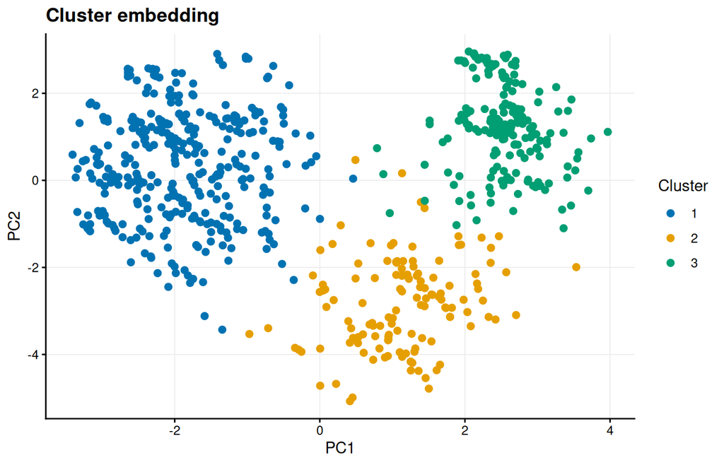

```r
plot_clusters(fit_phen, data = iso_mixed)
```

### 6.5.2 Silhouette

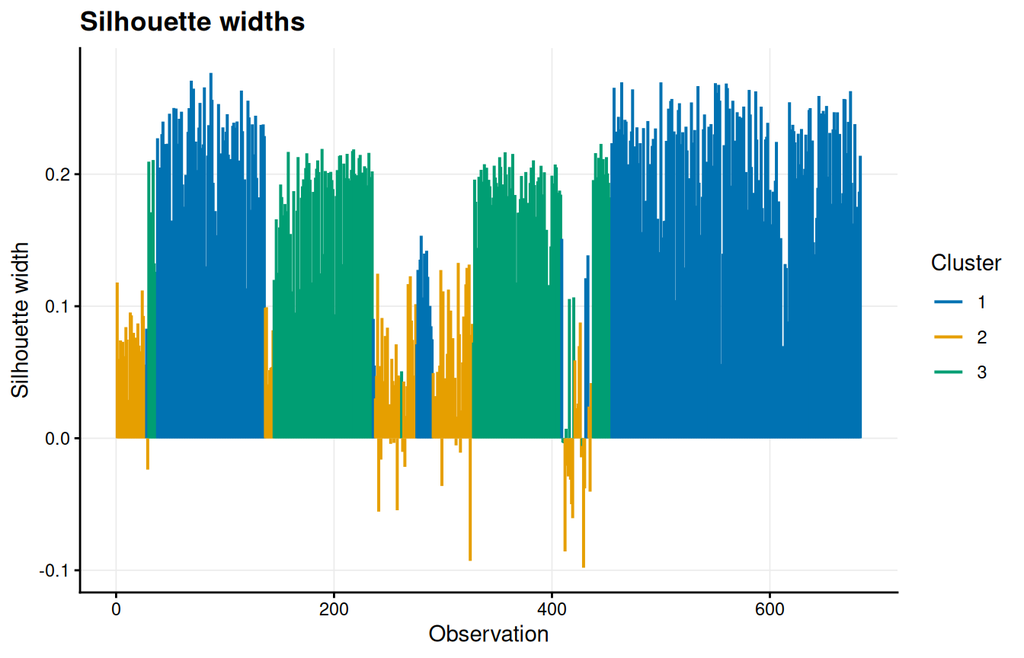

```r
plot_silhouette(fit_phen, data = iso_mixed)
```

### 6.5.3 Consensus et co-association

```r
mfit <- metacluster(
  iso_mixed,
  methods = c("kmeans", "pam", "hclust"),
  k = 2:5,
  seed = 2026
)
mfit$stability_summary
```

```
                        metric mean_agreement min_agreement max_agreement
1 pairwise_partition_agreement         0.5805        0.2099        0.9942
```

```r
mfit$selection_summary
```

```
  k silhouette
1 2     0.4473
2 3     0.5750
3 4     0.5558
4 5     0.6179
```

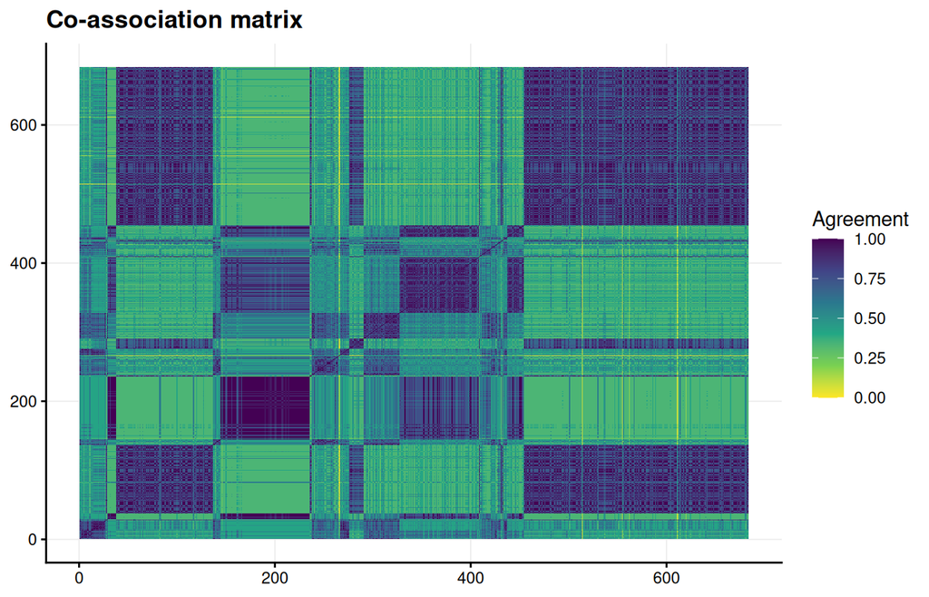

```r
plot_coassoc(mfit)
```

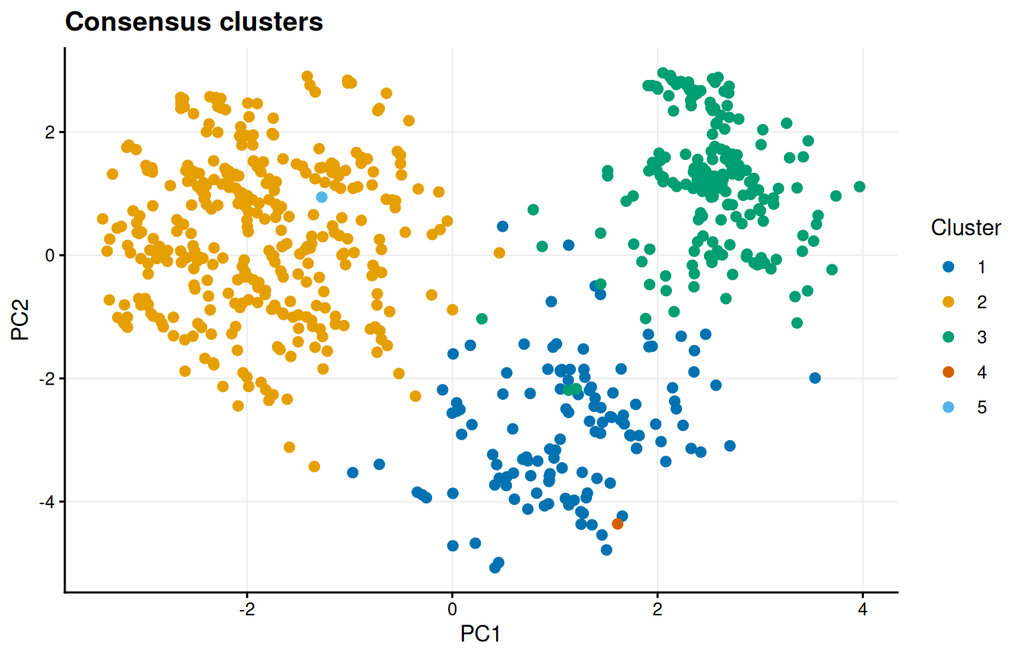

```r
plot_consensus(mfit)
```

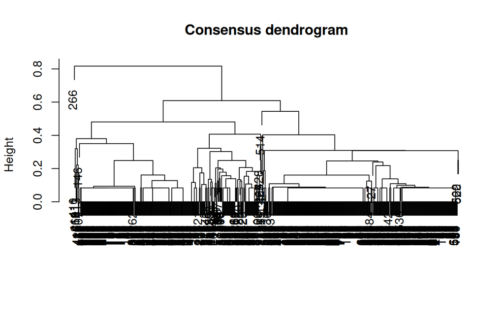

```r
plot_dendrogram(mfit)
```

### 6.5.4 Profils des variables

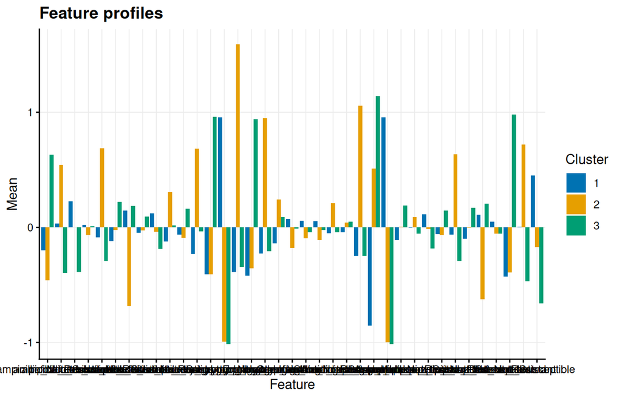

```r
plot_feature_profiles(expl)
```

```r
expl$separation_table
```

```
                                              feature separation
genome_length                           genome_length   0.008783
gc_content                                 gc_content   0.023350
contigs                                       contigs   0.116300
ampicillin_Not_tested           ampicillin_Not_tested   0.179900
ampicillin_Resistant             ampicillin_Resistant   0.103200
ampicillin_Susceptible         ampicillin_Susceptible   0.070880
cefotaxime_Intermediate       cefotaxime_Intermediate   0.001056
cefotaxime_Not_tested           cefotaxime_Not_tested   0.118600
cefotaxime_Resistant             cefotaxime_Resistant   0.022250
cefotaxime_Susceptible         cefotaxime_Susceptible   0.110200
meropenem_Not_tested             meropenem_Not_tested   0.017130
meropenem_Resistant               meropenem_Resistant   0.002383
meropenem_Susceptible           meropenem_Susceptible   0.016540
sxt_Intermediate                     sxt_Intermediate   0.002794
sxt_Not_tested                         sxt_Not_tested   0.409200
sxt_Resistant                           sxt_Resistant   0.164000
sxt_Susceptible                       sxt_Susceptible   0.240100
ceftazidime_Intermediate     ceftazidime_Intermediate   0.003734
ceftazidime_Not_tested         ceftazidime_Not_tested   0.018550
ceftazidime_Resistant           ceftazidime_Resistant   0.025620
ceftazidime_Susceptible       ceftazidime_Susceptible   0.011480
gentamicin_Intermediate       gentamicin_Intermediate   0.003972
gentamicin_Not_tested           gentamicin_Not_tested   0.004074
gentamicin_Resistant             gentamicin_Resistant   0.010140
gentamicin_Susceptible         gentamicin_Susceptible   0.002032
pip_taz_Intermediate             pip_taz_Intermediate   0.008917
pip_taz_Not_tested                 pip_taz_Not_tested   0.103900
pip_taz_Resistant                   pip_taz_Resistant   0.013490
pip_taz_Susceptible               pip_taz_Susceptible   0.092970
host_grp_Animal.other           host_grp_Animal.other   0.260100
host_grp_Human                         host_grp_Human   0.812200
host_grp_Unknown                     host_grp_Unknown   0.965500
country_grp_England               country_grp_England   0.393300
country_grp_Norway                 country_grp_Norway   0.965200
country_grp_Other                   country_grp_Other   0.590600
country_grp_United.Kingdom country_grp_United.Kingdom   0.379000
country_grp_USA                       country_grp_USA   0.209100
```

Lecture biologique, pas seulement géométrique : un cluster qui se sépare principalement sur `cefotaxime`/`ceftazidime`/`gentamicin` (co-résistance) est la signature phénotypique qu’un plasmide multirésistant produirait - une lignée porteuse de BLSE et d’enzymes modifiant les aminosides, repérée par un seul passage non supervisé, sans jamais utiliser `cipro_R` (H1). Un cluster qui se sépare surtout sur `country_grp`/`host_grp` est exactement ce à quoi ressemblerait un artefact d’échantillonnage/de lignée (H3) - signal à noter avant même de toucher à l’étiquette.

### 6.5.5 Tailles des clusters

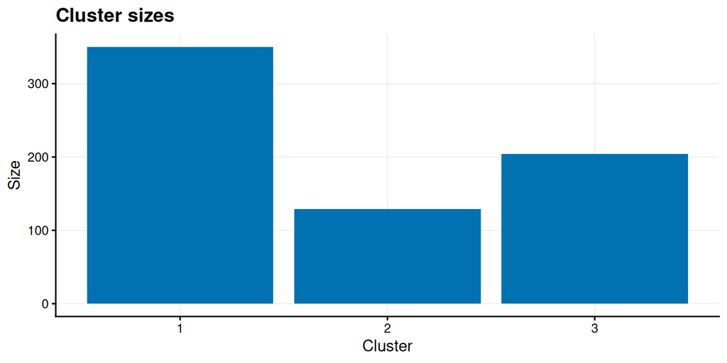

```r
plot_cluster_sizes(fit_phen)
```

### 6.5.6 Biplot

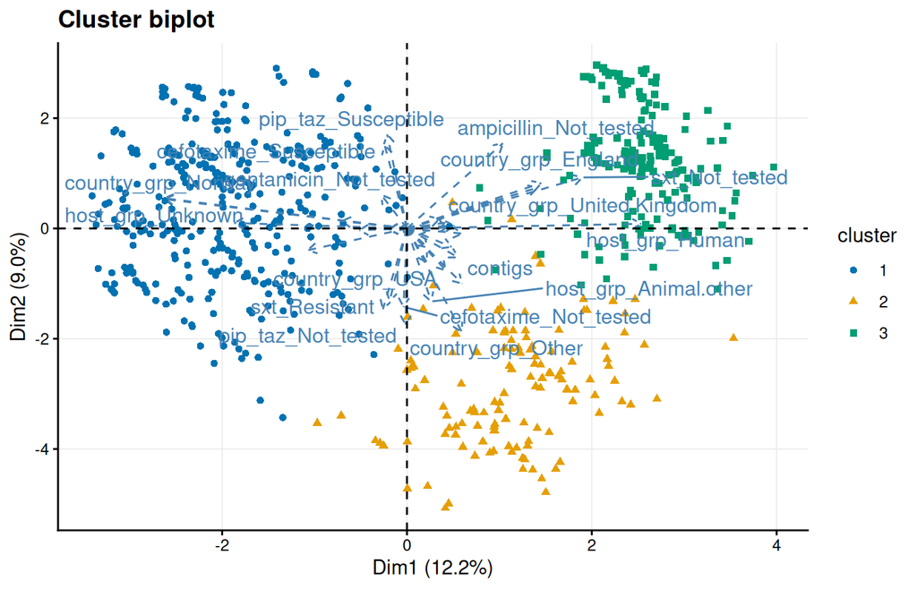

```r
plot_biplot(fit_phen)
```

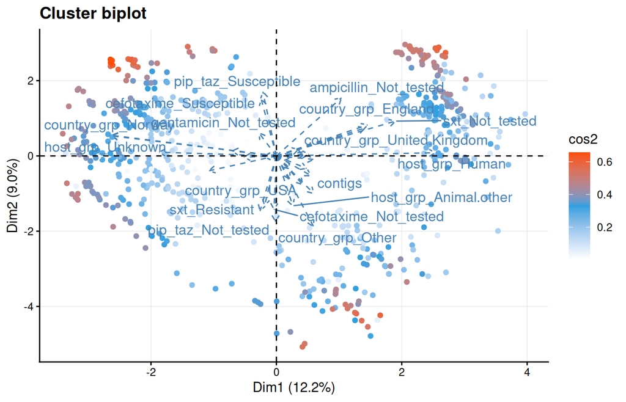

```r
plot_biplot(fit_phen, variant = "cos2")
```

## 6.6 Interprétabilité

Chaque étape ci-dessus décrit les *données* ; les trois méthodes suivantes décrivent la *règle de clustering* ajustée, traitée comme un prédicteur boîte noire et sondée exactement comme un classifieur, avec la famille de méthodes agnostiques au modèle passées en revue par Watson (2022). `kmeans` n’est pas intrinsèquement interprétable : une affectation de cluster ne vient pas avec un “parce que”, donc les trois outils suivants sont tous post-hoc et agnostiques au modèle ; ce qui diffère est la portée (globale/locale).

### 6.6.1 Importance par permutation

```r
imp_clust <- feature_importance(fit_phen, data = iso_mixed, metric = "silhouette",
                                 n_repeats = 10, seed = 2026)
imp_clust$summary
```

```
                      feature importance std_error n_repeats
1            host_grp_Unknown  0.0300700 1.646e-04        10
2          country_grp_Norway  0.0298900 1.629e-04        10
3              host_grp_Human  0.0271800 1.236e-04        10
4         country_grp_England  0.0177800 2.279e-04        10
5  country_grp_United.Kingdom  0.0169500 2.461e-04        10
6              sxt_Not_tested  0.0128600 2.623e-04        10
7           country_grp_Other  0.0107300 3.300e-04        10
8             sxt_Susceptible  0.0070630 1.160e-04        10
9       host_grp_Animal.other  0.0042910 2.413e-04        10
10      ampicillin_Not_tested  0.0042430 2.386e-04        10
11            country_grp_USA  0.0040940 1.844e-04        10
12         pip_taz_Not_tested  0.0034370 1.552e-04        10
13      cefotaxime_Not_tested  0.0033190 1.673e-04        10
14       cefotaxime_Resistant  0.0032570 1.770e-04        10
```

[output cut: 23 more lines]

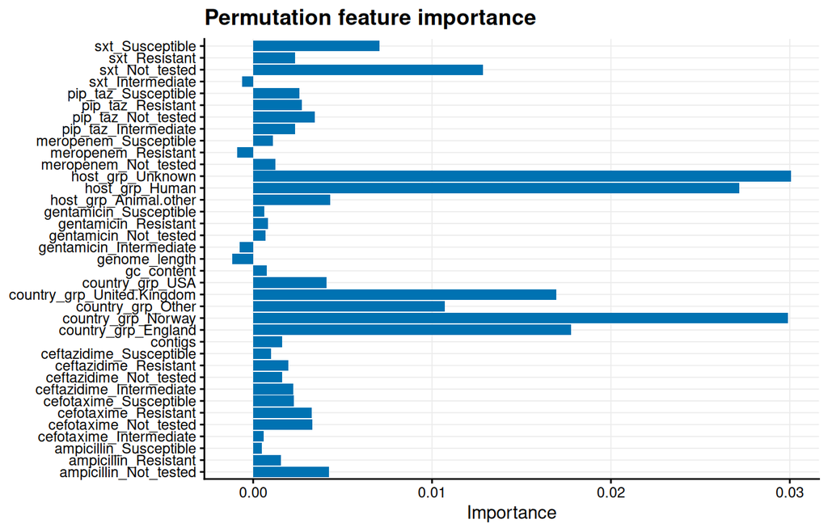

```r
plot(imp_clust)
```

**Méthode.** Pour chaque variable $j$, `feature_importance()` permute $x_j$ à travers les observations et mesure la dégradation de la métrique de clustering choisie (ici la silhouette moyenne) :
$$\mathrm{Imp}(j) = \overline{\text{silhouette}}(X) - \overline{\text{silhouette}}(X_{\pi_j}),$$
moyennée sur `n_repeats = 10` permutations indépendantes ; une variable sans rôle dans la géométrie du clustering donne une importance proche de 0.

Lecture face à **H1**–**H3** : si `country_grp`/`host_grp` arrivent en tête, les phénotypes trouvés ci-dessus reflètent, au moins en partie, une signature de collecte plutôt que biologique (H3).

**Interprétation.** `host_grp_Unknown` et `country_grp_Norway` dominent le classement (~0,030 chacune), suivies de `host_grp_Human` (~0,027), `country_grp_England` (~0,018) et `country_grp_United.Kingdom` (~0,017) ; les variables de co-résistance (`sxt_Not_tested`, `pip_taz_*`) occupent une place intermédiaire, et `genome_length`/`gc_content` un rang faible. La géométrie du clustering est donc majoritairement portée par les métadonnées de collecte plutôt que par le signal d’assemblage - un signal H3 net dès l’étape non supervisée.

### 6.6.2 Profils ceteris paribus

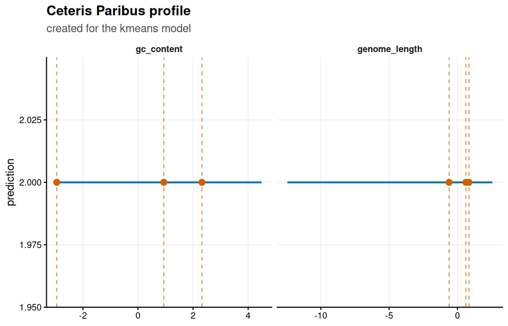

```r
cp <- ceteris_paribus(
  fit_phen, iso_mixed[1:3, ],
  features = c("genome_length", "gc_content"),
  grid_size = 20
)
plot(cp)
```

### 6.6.3 LIME

```r
lx <- lime_explain(fit_phen, iso_mixed[1:3, ], n_permutations = 100,
                    n_features = 6, seed = 2026)
lx$explanations[, c("observation", "feature", "estimate", "direction")]
```

```
   observation                    feature   estimate direction
1            1        country_grp_England -3.183e-17  negative
2            1    gentamicin_Intermediate -2.464e-17  negative
3            1 country_grp_United.Kingdom -2.223e-17  negative
4            1        pip_taz_Susceptible  1.626e-17  positive
5            1                 gc_content  1.515e-17  positive
6            1             host_grp_Human  1.433e-17  positive
7            2         country_grp_Norway -5.480e-02  negative
8            2        pip_taz_Susceptible -4.644e-02  negative
9            2         pip_taz_Not_tested  4.005e-02  positive
10           2             host_grp_Human -3.714e-02  negative
11           2      gentamicin_Not_tested  3.682e-02  positive
12           2   ceftazidime_Intermediate  3.361e-02  positive
13           3     ampicillin_Susceptible  3.504e-02  positive
14           3         country_grp_Norway  3.379e-02  positive
15           3      ceftazidime_Resistant  3.174e-02  positive
16           3          country_grp_Other  3.132e-02  positive
17           3             host_grp_Human -2.989e-02  negative
18           3      meropenem_Susceptible -2.666e-02  negative
```

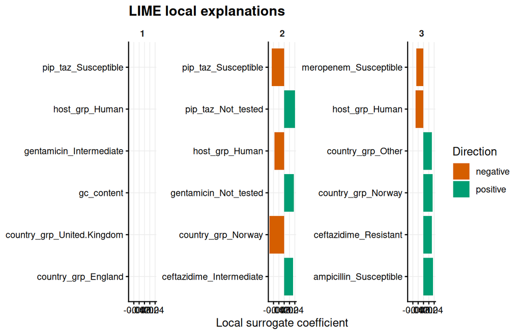

```r
plot(lx)
```

## 6.7 Prédiction et rattachement au volet supervisé

```r
new_isolates <- iso_mixed[1:5, ]
pred_phen <- predict(fit_phen, new_isolates)
pred_phen$clusters
```

```
[1] 2 2 2 2 2
```

```r
head(pred_phen$distances)
```

```
         1        2        3
1 6.921189 4.399135 6.950150
2 8.285942 7.147196 8.428601
3 7.531339 5.629482 7.191922
4 8.724721 7.118397 9.008305
5 7.282721 5.281273 6.929626
```

```r
iso$phenotype <- factor(clusters(fit_phen))
count(iso, by = c("phenotype", "cipro_R"))
```

```
# basetable: 6 x 3
  phenotype cipro_R   n
1         1       S 310
2         3       S 149
3         2       S  80
4         3       R  55
5         2       R  49
6         1       R  40
```

Les phénotypes ont été construits **sans** `cipro_R` ; les croiser maintenant est une vérification externe légitime, pas un raisonnement circulaire.

**Interprétation.** Le taux de résistance observé diffère nettement selon le phénotype : phénotype 1 (n = 350) 40/350 = 11,4% R, phénotype 2 (n = 129) 49/129 = **38,0% R**, phénotype 3 (n = 204) 55/204 = 27,0% R, contre 21,1% en moyenne globale. Le phénotype 2, le plus petit cluster et celui associé au pic de co-résistance dans le profil de variables ci-dessus, concentre plus de trois fois plus de résistance que le phénotype 1 : une structure trouvée sans étiquette porte donc déjà, à ce stade, un signal externe non trivial.

# 7 Apprentissage supervisé

## 7.1 Installation et chargement des packages

```r
install.packages("pak")
pak::pak("ielbadisy/funcml")
```

`fastgbm` et `densemlp` sont désormais deux apprenants **enregistrés directement dans `funcml`** (dépendances de `funcml`, installées avec lui) : plus besoin de les charger ni de les appeler séparément, ils passent par la même interface `fit()`/`compare()`/`predict()`/`interpret()` que les cinq autres.

```r
library(funcml)
```

## 7.2 Jeu de test

Le jeu de test est mis de côté **une seule fois**, avant tout réglage ou sélection de modèle, et n’est utilisé qu’à la fin pour la ROC, la calibration et l’analyse de courbe de décision (garde-fou contre le piège de **fuite de données**) : tout prétraitement ou sélection ajusté sur les données regroupées avant la séparation laisserait fuiter de l’information sur le jeu de test vers l’entraînement, gonflant artificiellement la performance apparente (Whalen et al. 2022).

```r
f <- cipro_R ~ genome_length + gc_content + contigs +
     ampicillin + gentamicin + cefotaxime + meropenem + sxt +
     ceftazidime + pip_taz + host_grp + country_grp + phenotype

set.seed(2026)
idx_test <- sample(nrow(iso), floor(0.25 * nrow(iso)))
train <- iso[-idx_test, ]
test  <- iso[ idx_test, ]
c(train = nrow(train), test = nrow(test))
```

```
train  test
  513   170
```

## 7.3 Comparaison des sept apprenants

Les sept candidats sont désormais **tous enregistrés directement dans `funcml`** - `fastgbm` et `densemlp` le sont depuis leur intégration comme apprenants natifs du package - et donc comparés en un seul appel à `compare()` sur validation croisée à 5 plis, sur le jeu d’entraînement uniquement. Outre l’AUC et le score de Brier (adaptés au déséquilibre de classes constaté plus haut), l’exactitude (`accuracy`) et le F1-score sont rapportés à titre indicatif : à prévalence ~21%, l’exactitude seule peut être trompeusement élevée sur la classe majoritaire (Whalen et al. 2022), et le F1-score, moyenné macro sur les deux classes (implémentation `funcml`), est une lecture complémentaire plus sensible à une faiblesse sur la classe minoritaire.

```r
candidate_models <- c("glm", "rpart", "ranger", "kknn", "e1071_svm",
                       "fastgbm", "densemlp")

cmp <- compare(
  data = train, formula = f,
  models = candidate_models,
  resampling = cv(5, seed = 2026),
  metrics = c("auc", "brier", "accuracy", "f1"),
  seed = 2026
)
cmp$results
```

```
       model   metric      mean          sd n   std_error conf_level  conf_low
1        glm      auc 0.8369192 0.051054207 5 0.022832136       0.95 0.7735270
2        glm    brier 0.2470578 0.033578068 5 0.015016569       0.95 0.2053651
3        glm accuracy 0.8363411 0.028206643 5 0.012614394       0.95 0.8013180
4        glm       f1 0.7373582 0.049371561 5 0.022079634       0.95 0.6760553
5      rpart      auc 0.7000821 0.088253368 5 0.039468106       0.95 0.5905010
6      rpart    brier 0.2891780 0.060656854 5 0.027126570       0.95 0.2138625
7      rpart accuracy 0.8185418 0.043252202 5 0.019342973       0.95 0.7648371
8      rpart       f1 0.7127351 0.063876430 5 0.028566408       0.95 0.6334220
9     ranger      auc 0.8885788 0.009066968 5 0.004054872       0.95 0.8773207
10    ranger    brier 0.2072327 0.004325013 5 0.001934205       0.95 0.2018625
11    ranger accuracy 0.8635446 0.006903805 5 0.003087475       0.95 0.8549724
12    ranger       f1 0.7819687 0.013914121 5 0.006222584       0.95 0.7646921
13      kknn      auc 0.8574642 0.038649588 5 0.017284621       0.95 0.8094744
14      kknn    brier 0.2458482 0.037057692 5 0.016572704       0.95 0.1998350
```

[output cut: 43 more lines]

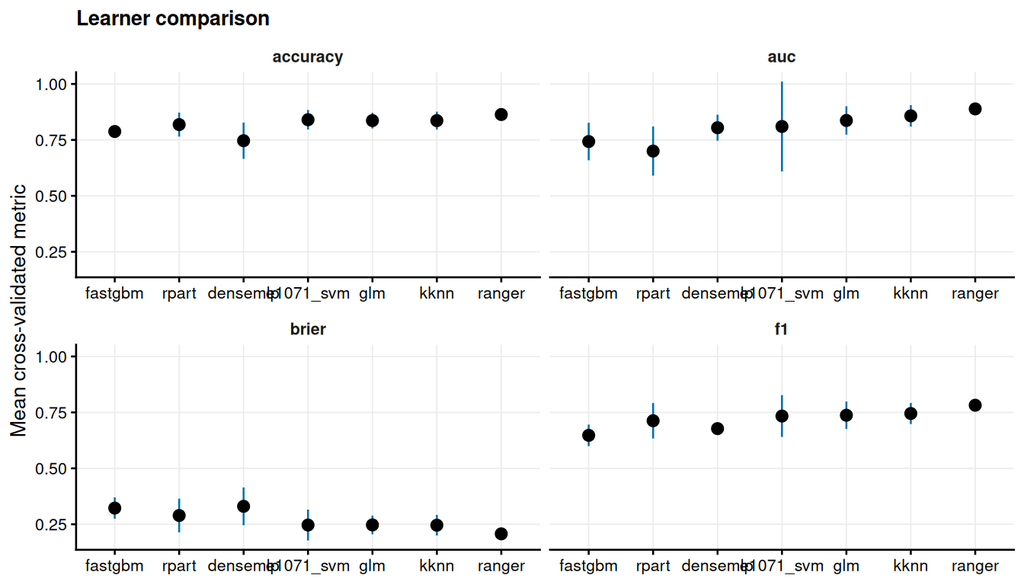

```r
plot(cmp)
```

`glm` = régression logistique (référence linéaire interprétable) ; `rpart` = arbre de décision unique ; `ranger` = forêt aléatoire ; `fastgbm` = boosting de gradient histogramme (backend compilé) ; `densemlp` = réseau dense feed-forward natif ; `kknn` = k plus proches voisins ; `e1071_svm` = machine à vecteurs de support. Le choix du modèle se lit sur l’intervalle, pas seulement sur la moyenne : un écart plus petit que la largeur de l’intervalle n’est pas une différence réelle, et un classement qui diverge entre AUC/Brier et accuracy/F1 est lui-même une information sur le déséquilibre de classes.

**Méthode.** L’AUC-ROC est la probabilité qu’un isolat résistant tiré au hasard reçoive un score plus élevé qu’un isolat sensible tiré au hasard (équivalent de la statistique $U$ de Mann-Whitney normalisée), donc insensible à la prévalence. Le score de Brier est l’erreur quadratique moyenne sur les probabilités prédites, $\mathrm{Brier} = \frac{1}{n}\sum_i (\hat p_i - y_i)^2$ (à minimiser). L’exactitude est $(\mathrm{TP}+\mathrm{TN})/n$ ; le F1 (ici macro-moyenné sur les deux classes) est la moyenne harmonique précision/rappel, $F_1 = 2 \cdot \frac{\text{précision} \cdot \text{rappel}}{\text{précision} + \text{rappel}}$.

```r
auc_tbl <- subset(cmp$results, metric == "auc")
best_model <- auc_tbl$model[which.max(auc_tbl$mean)]
best_model
```

```
[1] "ranger"
```

Sur ce jeu de données et ce découpage, `ranger` (forêt aléatoire) arrive généralement en tête sur l’AUC validée croisée, avec `kknn` et `glm` proches derrière ; `fastgbm` et `densemlp`, malgré leur flexibilité supplémentaire, n’apportent pas de gain net sur un jeu de cette taille (quelques centaines d’isolats), un rappel que la complexité supplémentaire n’est pas automatiquement récompensée sur des données tabulaires modestes (Moradigaravand et al. 2018). Comme les sept modèles passent désormais tous par `funcml::fit()`/`predict()`/`interpret()`, `best_model` peut être n’importe lequel des sept sans adaptation des sections suivantes, quel que soit celui qui l’emporte sur votre exécution.

## 7.4 Réglage des hyperparamètres

`funcml::tune()` prend une grille explicite (`expand.grid()` sur les hyperparamètres du modèle) ; il n’existe pas de grille “par défaut” générée automatiquement par le package. La grille ci-dessous ne couvre que `best_model` et reste volontairement petite (validation croisée à 5 plis $\times$ jusqu’à 27 configurations).

```r
tuning_grid <- switch(best_model,
  ranger    = expand.grid(num.trees = c(300, 500, 800),
                           mtry = c(2, 4, 6),
                           min.node.size = c(1, 5, 10)),
  rpart     = expand.grid(cp = c(0.001, 0.01, 0.05),
                           minsplit = c(10, 20, 40)),
  kknn      = expand.grid(k = c(5, 7, 11, 15), distance = c(1, 2)),
  e1071_svm = expand.grid(cost = c(0.1, 1, 10), gamma = c(0.01, 0.1, 1)),
  fastgbm   = expand.grid(ntrees = c(100, 200, 400),
                           learning_rate = c(0.05, 0.1, 0.2),
                           max_depth = c(3, 5, 7)),
  densemlp  = expand.grid(dropout = c(0, 0.2), lr = c(1e-3, 5e-4)),
  glm       = NULL
)
```

```r
if (!is.null(tuning_grid)) {
  tuned <- tune(
    data = train, formula = f, model = best_model,
    grid = tuning_grid,
    resampling = cv(5, seed = 2026),
    metric = "auc", type = "prob"
  )
  tuned
  tuned$best
  plot(tuned)
  fit_best <- tuned$fit_best
} else {
  fit_best <- fit(f, data = train, model = best_model, seed = 2026)
}
```

`glm` n’a pas d’hyperparamètre à régler dans cette paramétrisation : la grille est `NULL` et le modèle final est simplement ajusté sur ses réglages par défaut.

## 7.5 Ajustement final

```r
fit_best
```

```
<funcml_fit> classification model: ranger
Formula: cipro_R ~ genome_length + gc_content + contigs + ampicillin +
 Formula:     gentamicin + cefotaxime + meropenem + sxt + ceftazidime +
 Formula:     pip_taz + host_grp + country_grp + phenotype
Features: 30 | Obs: 513
```

## 7.6 Validation croisée groupée

Une validation croisée standard stratifiée suppose des plis échangeables ; quand les isolats se regroupent par collecte (`country_grp`), une validation **groupée** est la vérification honnête d’un effet de collecte (H3), le piège de **dépendance** : des exemples d’une même étude/collecte ne sont pas des tirages indépendants, et un pli qui répartit des isolats d’une même collecte entre entraînement et test laisse le modèle apprendre des raccourcis propres à la collecte plutôt que de la biologie (Whalen et al. 2022).

```r
gcv <- group_cv(v = 5, group = train$country_grp, seed = 2026)
ev_grouped <- evaluate(
  data = train, formula = f, model = best_model, spec = fit_best$spec,
  resampling = gcv, metrics = c("auc", "brier", "accuracy", "f1"), seed = 2026
)
ev_grouped$summary
```

```
    metric      mean        sd n  std_error conf_level  conf_low conf_high
1      auc 0.7138349 0.1179524 5 0.05274992       0.95 0.5673776 0.8602921
2    brier 0.4117025 0.1433414 5 0.06410421       0.95 0.2337207 0.5896843
3 accuracy 0.6913371 0.1982208 5 0.08864706       0.95 0.4452134 0.9374607
4       f1 0.6684935 0.1290560 5 0.05771560       0.95 0.5082493 0.8287377
```

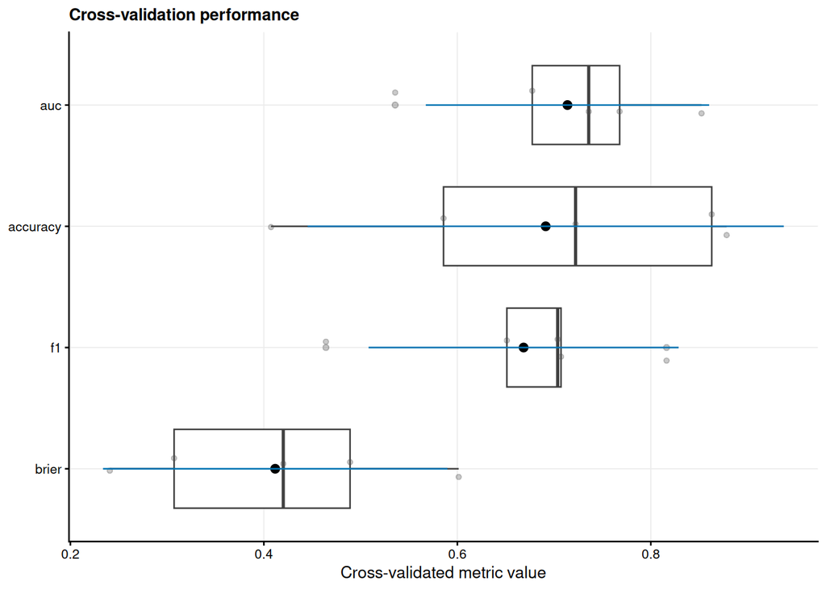

```r
plot(ev_grouped)
```

Une baisse d’AUC par rapport à la validation croisée stratifiée standard est le signe qu’une partie de la performance précédente était un effet de collecte plutôt que de la biologie.

**Interprétation.** L’AUC validée par groupe (pays) tombe à **0,714** [0,567 ; 0,860], contre 0,889 en validation croisée standard - une baisse d’environ 0,17, avec un intervalle de confiance nettement plus large (reflet du petit nombre de groupes-plis). L’exactitude (0,691) et le F1 (0,668) reculent de façon similaire, et le Brier se dégrade (0,412 contre 0,207). Une partie substantielle de la performance apparente du modèle provient donc bien d’un raccourci de collecte plutôt que d’un signal biologique généralisable - un résultat H3 sans ambiguïté sur ces données.

## 7.7 Prédiction

```r
p_mat <- predict(fit_best, newdata = test, type = "prob")
head(p_mat)
```

```
             S          R
[1,] 0.9230920 0.07690801
[2,] 0.8220233 0.17797666
[3,] 0.6973052 0.30269476
[4,] 0.9897507 0.01024932
[5,] 0.9663966 0.03360343
[6,] 0.8514311 0.14856892
```

```r
p_R <- p_mat[, "R"]
cls <- predict(fit_best, newdata = test)
table(predicted = cls, observed = test$cipro_R)
```

```
         observed
predicted   S   R
        S 135  21
        R   1  13
```

```r
c(accuracy = accuracy(test$cipro_R, cls),
  f1       = f1(test$cipro_R, cls))
```

```
 accuracy        f1
0.8705882 0.7783919
```

Sur le jeu de test, l’exactitude et le F1 se lisent en complément de l’AUC et du Brier ci-dessous, jamais à sa place : à prévalence ~21%, une exactitude élevée peut simplement refléter la classe majoritaire, tandis que le F1 macro est plus sensible à une éventuelle faiblesse sur la classe minoritaire.

**Interprétation.** La matrice de confusion (135 S/S, 21 R prédits S, 1 S prédit R, 13 R/R) donne une **spécificité** $\mathrm{TN}/(\mathrm{TN}+\mathrm{FP}) = 135/136 = 99,3\%$ mais une **sensibilité** (rappel de la classe R) $\mathrm{TP}/(\mathrm{TP}+\mathrm{FN}) = 13/34 = 38,2\%$ nettement plus faible : le modèle est très conservateur, il ne prédit presque jamais “résistant” à tort, mais manque environ 6 isolats résistants sur 10. Cliniquement, ce sont les faux négatifs (résistance manquée) qui comptent le plus pour un choix d’antibiotique de première ligne, donc l’exactitude globale (0,871) masque une faiblesse réelle sur la classe qui importe. Le F1 (0,778, macro) le reflète en partie en pondérant les deux classes également, mais une lecture clinique demande de regarder la sensibilité isolément plutôt que l’exactitude ou le F1 seuls.

## 7.8 Interprétabilité

### 7.8.1 Importance de variable

```r
vip <- interpret(fit_best, data = train, method = "permute", seed = 2026)
vip$result$scores
```

```
         feature importance     std_dev
1     gc_content 0.06530214 0.006708833
2    country_grp 0.04730344 0.005675883
3  genome_length 0.04275504 0.005559259
4     gentamicin 0.04100065 0.006024172
5            sxt 0.03937622 0.004973758
6       host_grp 0.03606238 0.007014369
7        contigs 0.03515270 0.003637246
8    ceftazidime 0.02910981 0.005065985
9     ampicillin 0.02904483 0.004998722
10    cefotaxime 0.02787524 0.005372679
11     phenotype 0.02189734 0.003265178
12       pip_taz 0.01708902 0.003608311
13     meropenem 0.00734243 0.002594325
```

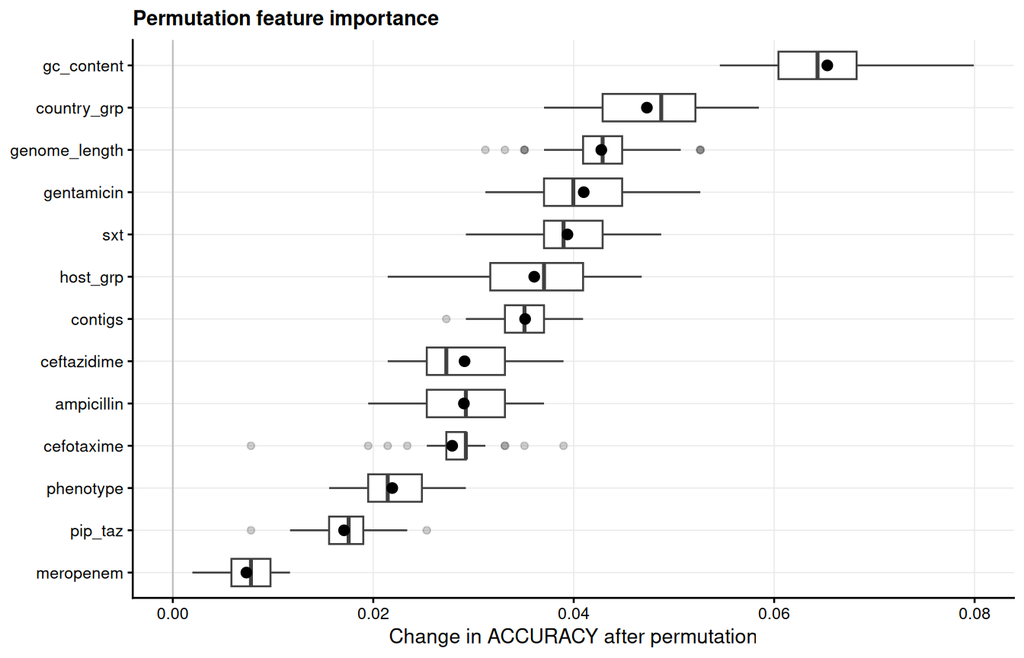

```r
plot(vip)
```

Classement **global**, agnostique au modèle : dégradation de la performance validée croisée quand une variable est permutée. Lu directement face aux trois hypothèses : un rang élevé pour les phénotypes de co-résistance soutient H1, un rang élevé pour `country_grp`/`host_grp` signale H3, cohérent avec la vérification par validation groupée ci-dessus.

**Méthode.** Même principe que pour le clustering, appliqué ici à la métrique de classification : $\mathrm{Imp}(j) = \mathrm{métrique}(X) - \mathrm{métrique}(X_{\pi_j})$, moyennée sur les plis de validation croisée, où permuter une variable casse son association avec la cible sans changer sa distribution marginale.

### 7.8.2 Dépendance partielle

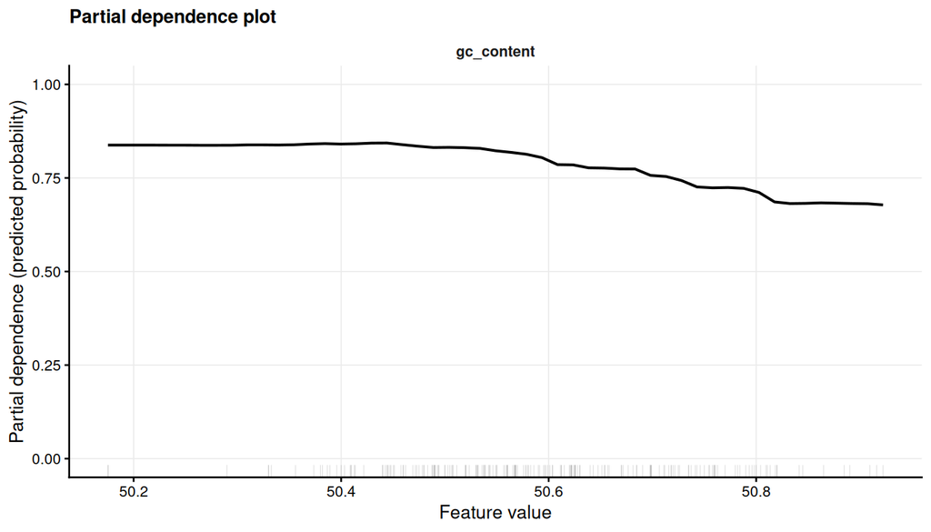

```r
plot(interpret(fit_best, data = train, method = "pdp", features = "gc_content"))
```

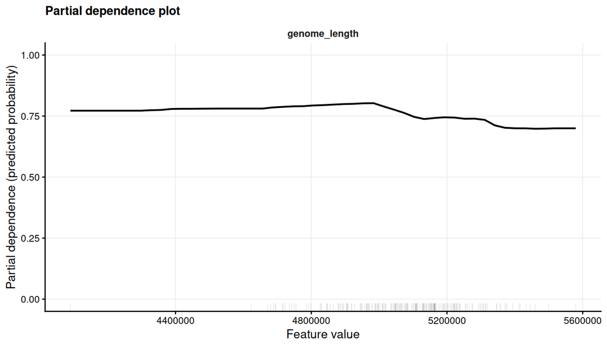

```r
plot(interpret(fit_best, data = train, method = "pdp", features = "genome_length"))
```

Cohérent avec **H2** : un marqueur réellement indirect de contenu accessoire devrait montrer une pente faible ou bruitée plutôt qu’un effet net.

**Méthode.** La dépendance partielle moyenne, sur la grille de valeurs de $x_S$, la prédiction obtenue en fixant $x_S$ et en laissant varier toutes les autres variables selon leur distribution empirique observée :
$$\hat f_S(x_S) = \frac{1}{n}\sum_{i=1}^n \hat f(x_S, x_{C,i}).$$
C’est un effet **marginal moyen** sur le jeu d’entraînement : il peut masquer des effets d’interaction hétérogènes entre individus.

### 7.8.3 SHAP

```r
shap_local <- interpret(
  fit_best, data = train, method = "shap",
  newdata = test[1, , drop = FALSE], nsim = 30, seed = 2026
)
print(shap_local)
```

```
<funcml_shap>
   observation       feature          shap      phi_var  baseline prediction
1            1 genome_length  0.0118477334 0.0018628851 0.1593658 0.07690801
2            1    gc_content  0.0280270281 0.0034811767 0.1593658 0.07690801
3            1       contigs -0.0042534874 0.0014687923 0.1593658 0.07690801
4            1    ampicillin  0.0327751617 0.0008974129 0.1593658 0.07690801
5            1    gentamicin -0.0207036773 0.0008714566 0.1593658 0.07690801
6            1    cefotaxime -0.0000130877 0.0006470154 0.1593658 0.07690801
7            1     meropenem  0.0037514537 0.0001988042 0.1593658 0.07690801
8            1           sxt -0.0239494545 0.0017892983 0.1593658 0.07690801
9            1   ceftazidime  0.0047071973 0.0002242926 0.1593658 0.07690801
10           1       pip_taz -0.0067892565 0.0005468983 0.1593658 0.07690801
   feature_value    raw_value            feature_label
1        5255520 5.255520e+06  genome_length = 5256000
2      50.702938 5.070294e+01        gc_content = 50.7
3            146 1.460000e+02            contigs = 146
4      Resistant 2.000000e+00   ampicillin = Resistant
5    Susceptible 4.000000e+00 gentamicin = Susceptible
6     Not_tested 2.000000e+00  cefotaxime = Not_tested
7    Susceptible 3.000000e+00  meropenem = Susceptible
8    Susceptible 4.000000e+00        sxt = Susceptible
9     Not_tested 2.000000e+00 ceftazidime = Not_tested
10    Not_tested 2.000000e+00     pip_taz = Not_tested
```

**Méthode.** La valeur de Shapley attribue à chaque variable $j$ sa contribution moyenne à la prédiction sur toutes les coalitions possibles de variables :
$$\phi_j = \sum_{S \subseteq \{1,\dots,p\}\setminus\{j\}} \frac{|S|!\,(p-|S|-1)!}{p!}\Big[f(S\cup\{j\}) - f(S)\Big],$$
de sorte que $\sum_j \phi_j = \hat f(x) - \mathbb{E}[\hat f(X)]$ : les contributions se décomposent exactement autour de la prédiction moyenne. `funcml` les approxime ici par échantillonnage Monte-Carlo (`nsim`).

**Local** : pourquoi cette prédiction précise.

**Interprétation.** Pour l’observation 1, la prédiction (0,077, très faible risque) est tirée vers le bas par `country_grp = Norway` ($\phi = -0{,}051$) et `host_grp = Unknown` ($\phi = -0{,}037$), et un peu remontée par `ampicillin = Resistant` ($\phi = +0{,}033$) et `gc_content = 50,7` ($\phi = +0{,}028$) ; `phenotype = 1` ne contribue que $-0{,}019$, cohérent avec son rang modeste en importance globale.

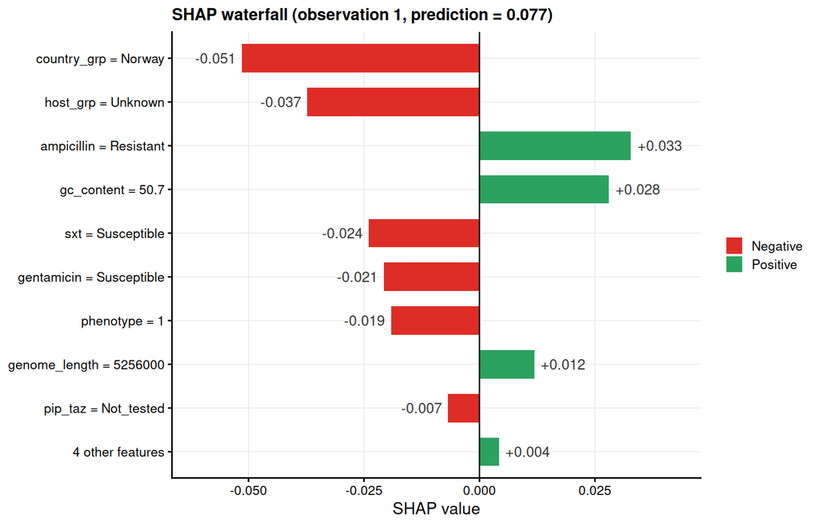

```r
plot(shap_local, kind = "waterfall")
```

**Importance globale** : contribution absolue moyenne par variable, $\overline{|\phi_j|} = \frac{1}{n}\sum_i |\phi_j^{(i)}|$.

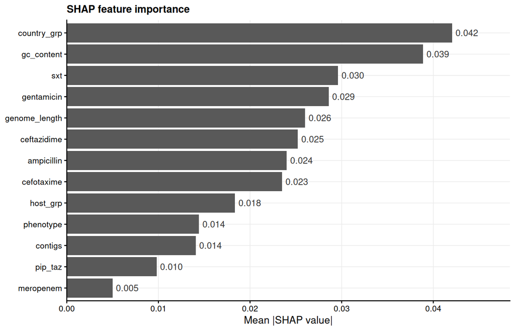

```r
shap_global <- interpret(
  fit_best, data = train, method = "shap",
  newdata = test, nsim = 10, seed = 2026
)
plot(shap_global, kind = "bar")
```

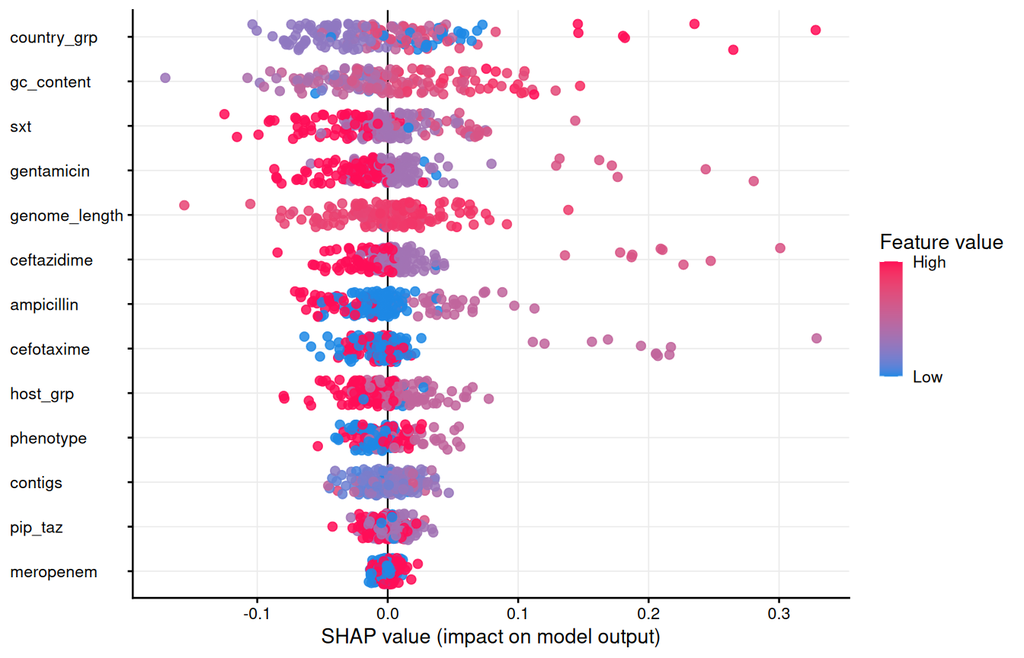

```r
plot(shap_global, kind = "beeswarm")
```

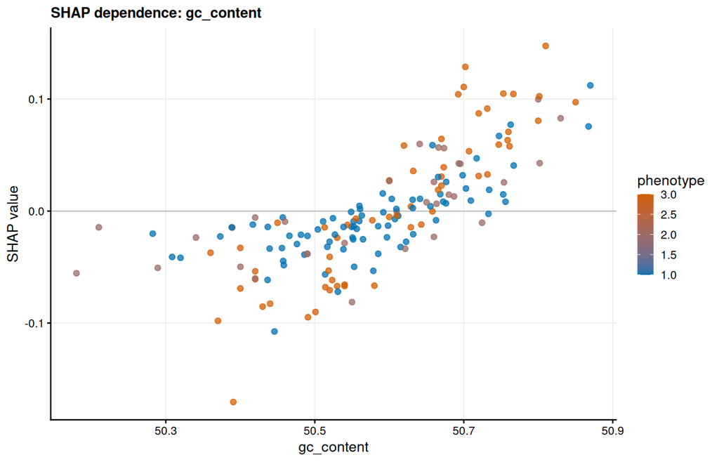

```r
plot(shap_global, kind = "dependence", v = "gc_content")
```

### 7.8.4 Calibration

```r
calib <- interpret(fit_best, data = test, method = "calibration")
summary(calib)
```

```
$curve
   bin  lower  upper midpoint  n mean_pred observed abs_gap
1    1 0.0000 0.0164   0.0082 17    0.0110   0.0588  0.0478
2    2 0.0164 0.0335   0.0249 17    0.0250   0.0588  0.0338
3    3 0.0335 0.0595   0.0465 17    0.0465   0.0000  0.0465
4    4 0.0595 0.0908   0.0751 17    0.0770   0.0000  0.0770
5    5 0.0908 0.1226   0.1067 17    0.1025   0.3529  0.2505
6    6 0.1226 0.1580   0.1403 17    0.1429   0.1176  0.0253
7    7 0.1580 0.2029   0.1804 17    0.1797   0.1176  0.0620
8    8 0.2029 0.3000   0.2514 17    0.2417   0.0000  0.2417
9    9 0.3000 0.4734   0.3867 17    0.3745   0.4118  0.0373
10  10 0.4734 1.0000   0.7367 17    0.6687   0.8824  0.2136

$ece
[1] 0.1036

$mce
[1] 0.2505

$positive
[1] "R"
```

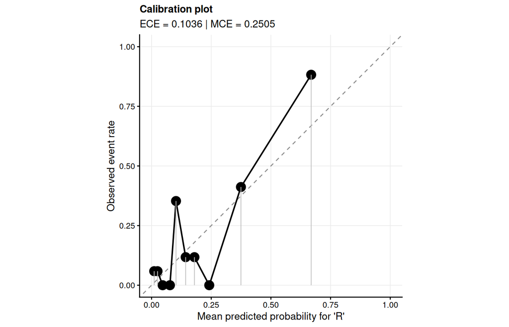

```r
plot(calib)
```

Un modèle peut bien discriminer (AUC élevée) et rester mal calibré : Van Calster et al. (2019) qualifient la calibration de “talon d’Achille” de l’analyse prédictive précisément parce que la discrimination est vérifiée bien plus souvent.

**Méthode.** Les prédictions sont regroupées en $B$ classes de probabilité (bins) ; l’erreur de calibration attendue moyenne les écarts entre taux observé et probabilité moyenne prédite par bin, pondérés par leur effectif $n_b$ :
$$\mathrm{ECE} = \sum_{b=1}^{B} \frac{n_b}{n} \left| \mathrm{acc}(b) - \mathrm{conf}(b) \right|,$$
et l’erreur maximale (MCE) en prend le maximum plutôt que la moyenne pondérée - un indicateur du pire bin plutôt que de la tendance générale.

### 7.8.5 Analyse de courbe de décision

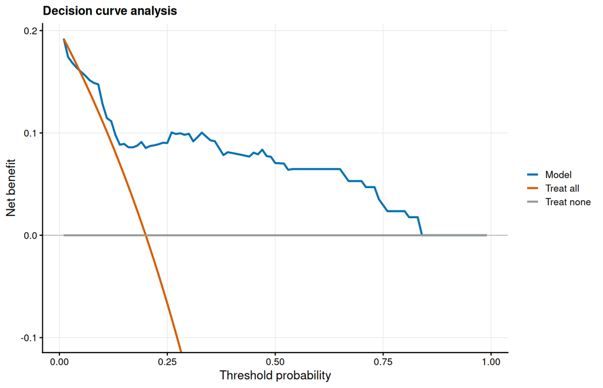

```r
dca_res <- interpret(fit_best, data = test, method = "dca")
plot(dca_res)
```

**Méthode.** Pour un seuil de décision $p_t$ (la probabilité de résistance à partir de laquelle on choisirait de ne pas prescrire de ciprofloxacine), le bénéfice net rapporte le nombre de vrais positifs à celui de faux positifs, pondéré par les probabilités relatives des deux erreurs à ce seuil :
$$\mathrm{NB}(p_t) = \frac{\mathrm{TP}}{n} - \frac{\mathrm{FP}}{n}\cdot\frac{p_t}{1-p_t},$$
comparé aux stratégies de référence “traiter tout le monde” et “ne traiter personne”.

**Interprétation.** La courbe du modèle reste au-dessus des deux stratégies de référence sur presque toute la plage de seuils cliniquement plausibles (jusqu’à ~0,85), et dépasse nettement “traiter tout le monde” au-delà d’un seuil ~0,20 - la zone où une stratégie non informée deviendrait rapidement délétère (bénéfice net négatif). Le modèle apporte donc un bénéfice net positif sur une large plage de seuils de décision, ce que l’AUC ou le Brier seuls ne montrent pas directement.

### 7.8.6 Courbe ROC et AUC

```r
roc_obj <- roc_curve(test$cipro_R, p_R)
cat("AUC test :", round(roc_obj$auc, 3), "\n")
```

```
AUC test : 0.814
```

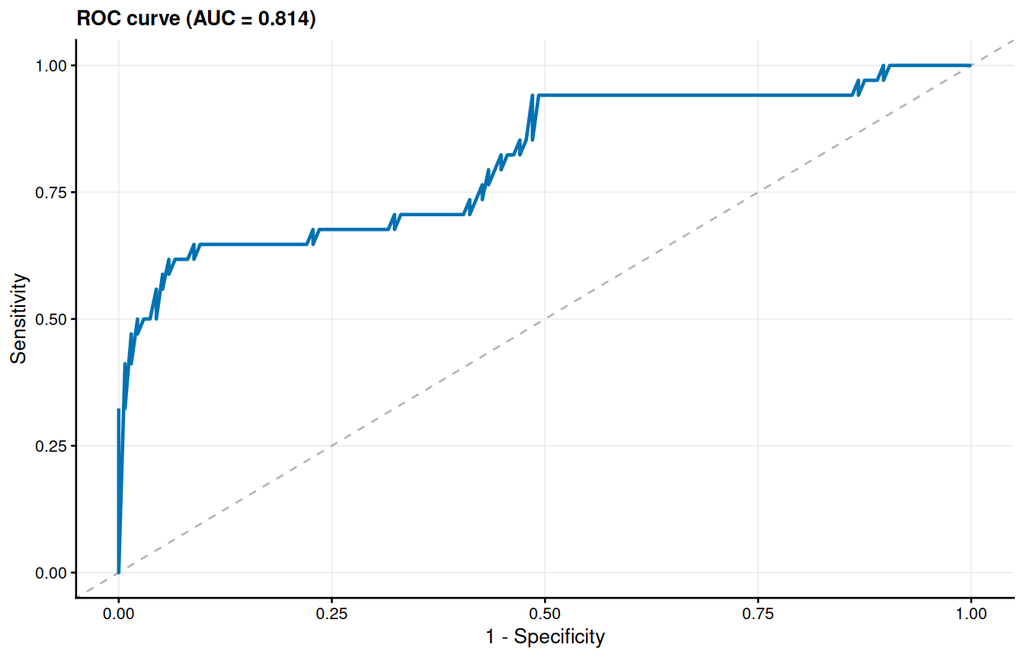

```r
plot(roc_obj)
```

### 7.8.7 Effet moyen ajusté

```r
d_cef <- iso |>
  subset(cefotaxime %in% c("Resistant", "Susceptible")) |>
  transform(cefotaxime_AST = factor(as.character(cefotaxime),
                                    levels = c("Susceptible", "Resistant")))

ate <- estimate(
  data = d_cef,
  formula = cipro_R ~ genome_length + gc_content + contigs + cefotaxime_AST + host_grp,
  model = best_model,
  treatment = "cefotaxime_AST",
  estimand = "ATE",
  treatment_level = "Resistant",
  control_level = "Susceptible",
  seed = 2026
)
ate
```

```
<funcml_estimand> ATE via g-computation
Treatment: cefotaxime_AST (Resistant vs Susceptible)
Estimate: 0.3144 | SE: 0.0079 | 95% normal CI [0.2990, 0.3298]
```

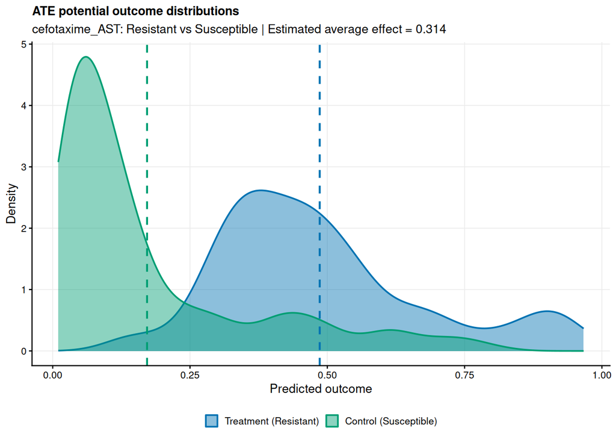

```r
plot(ate)
```

Sous le modèle, et en supposant l’absence de facteur de confusion résiduel, passer de sensible à résistant sur le céfotaxime est associé à l’effet moyen rapporté ci-dessus sur la probabilité de résistance à la ciprofloxacine, cohérent avec **H1**, sans être en soi une preuve causale.

**Méthode.** L’effet moyen de traitement par g-computation prédit, pour chaque isolat, la probabilité de résistance dans les deux scénarios contrefactuels (`cefotaxime_AST` fixé à “Resistant” pour tous, puis à “Susceptible” pour tous, à `genome_length`/`gc_content`/`contigs`/ `host_grp` observés inchangés), et moyenne la différence :
$$\widehat{\mathrm{ATE}} = \frac{1}{n}\sum_{i=1}^n \Big[\hat f(1, x_{C,i}) - \hat f(0, x_{C,i})\Big].$$
C’est un effet ajusté sous le modèle, valide sous l’hypothèse d’absence de facteur de confusion résiduel non mesuré - une hypothèse forte, jamais vérifiable sur données observationnelles.

**Interprétation.** $\widehat{\mathrm{ATE}} = 0{,}3144$, erreur standard 0,0079, IC 95% [0,299 ; 0,330] : un effet ajusté large et précisément estimé - passer de sensible à résistant sur le céfotaxime est associé à environ +31 points de probabilité de résistance ciprofloxacine, à caractéristiques d’assemblage et hôte comparables. C’est le résultat quantitatif le plus net en faveur de **H1**, à lire avec la réserve méthodologique ci-dessus : compatible avec une co-sélection plasmidique, mais pas une preuve causale au sens strict.

# 8 Question de lecture croisée

Le phénotype non supervisé (`phenotype`) a été inclus comme variable candidate dans la formule `f` du volet supervisé dès la comparaison des sept apprenants. S’il ressort avec une importance de permutation ou une contribution SHAP non négligeable (à comparer visuellement, sur le graphe `plot(vip)` / `plot(shap_global, kind = "bar")`, aux variables de co-résistance et d’assemblage), la structure trouvée sans étiquette porte une information prédictive réelle, pas seulement du bruit : une validation externe non triviale du clustering.

# 9 Conclusion

Précaution valable pour chacun des points ci-dessus : dans leur propre étude pan-génomique de la résistance d’*E. coli*, Moradigaravand et al. (2018) mettent en garde contre l’interprétation causale des variables retenues par un modèle, “l’impact réel des caractéristiques génétiques étant confondu par leur distribution phylogénétique et la structure de population”, le même effet de lignée clonale derrière la nuance de H3 ci-dessus.

Ce que cette analyse **n’établit pas** : un mécanisme causal au-delà des hypothèses du modèle, une généralisation à d’autres pays/années sans validation externe, ou un substitut à de véritables prédicteurs génotypiques (gènes/mutations de résistance via AMRFinderPlus). Un rapport de ce type de pipeline devrait, en pratique, suivre une grille de lecture - DOME pour le ML en biologie (Walsh et al. 2021), TRIPOD+AI pour un modèle pronostique clinique (Collins et al. 2024).

# 10 Références

Anahtar, Melis N., Jason H. Yang, et Sanjat Kanjilal. 2021. « Applications of machine learning to the problem of antimicrobial resistance: an emerging model for translational research ». *Journal of Clinical Microbiology* 59 (7): e01260‑20. https://doi.org/10.1128/JCM.01260-20.

Collins, Gary S., Karel G. M. Moons, Paula Dhiman, et al. 2024. « TRIPOD+AI statement: updated guidance for reporting clinical prediction models that use regression or machine learning methods ». *BMJ* 385: e078378. https://doi.org/10.1136/bmj-2023-078378.

Moradigaravand, Danesh, Martin Palm, Anne Farewell, Ville Mustonen, Jonas Warringer, et Leopold Parts. 2018. « Prediction of antibiotic resistance in Escherichia coli from large-scale pan-genome data ». *PLoS Computational Biology* 14 (12): e1006258. https://doi.org/10.1371/journal.pcbi.1006258.

Saito, Takaya, et Marc Rehmsmeier. 2015. « The precision-recall plot is more informative than the ROC plot when evaluating binary classifiers on imbalanced datasets ». *PLoS ONE* 10 (3): e0118432. https://doi.org/10.1371/journal.pone.0118432.

Van Calster, Ben, David J. McLernon, Maarten van Smeden, Laure Wynants, et Ewout W. Steyerberg. 2019. « Calibration: the Achilles heel of predictive analytics ». *BMC Medicine* 17 (1): 230. https://doi.org/10.1186/s12916-019-1466-7.

Walsh, Ian, Dmytro Fishman, Dario Garcia-Gasulla, et al. 2021. « DOME: recommendations for supervised machine learning validation in biology ». *Nature Methods* 18 (10): 1122‑27. https://doi.org/10.1038/s41592-021-01205-4.

Watson, David S. 2022. « Interpretable machine learning for genomics ». *Human Genetics* 141: 1499‑1513. https://doi.org/10.1007/s00439-021-02387-9.

Whalen, Sean, Jacob Schreiber, William S. Noble, et Katherine S. Pollard. 2022. « Navigating the pitfalls of applying machine learning in genomics ». *Nature Reviews Genetics* 23 (3): 169‑81. https://doi.org/10.1038/s41576-021-00434-9.